# Gemiddelde leeftijden leningen nieuwe auto’s en gebruikte auto’s

Arie Twigt

2023-11-21

# Inleiding

Onze klanten sluiten leningen af voor *gebruikte* auto’s en *nieuwe* auto’s. In dit onderzoek willen we testen of de gemiddelde leeftijden tussen deze twee groepen **significant** verschilt.

# Hypotheses

**H0**: De gemiddelde leeftijden voor leners van gebuikte auto’s en nieuwe auto’s verschillen **niet** significant.

**H1**: De gemiddelde leeftijden voor leners van gebuikte auto’s en nieuwe auto’s verschillen **wel** significant.

# Verdeling van de data bekijken

## Subset creeeren voor de redenen van leningen waar wij uitspraken over doen

```r
data_auto_leningen <- data %>%
  filter(purpose %in% c("car (new)", "car (used)"))
```

# Betrouwbaarheids

Voor deze test, stellen wij een betrouwbaarheidsinterval vast van **95%**.

## Visualiseer de verdeling

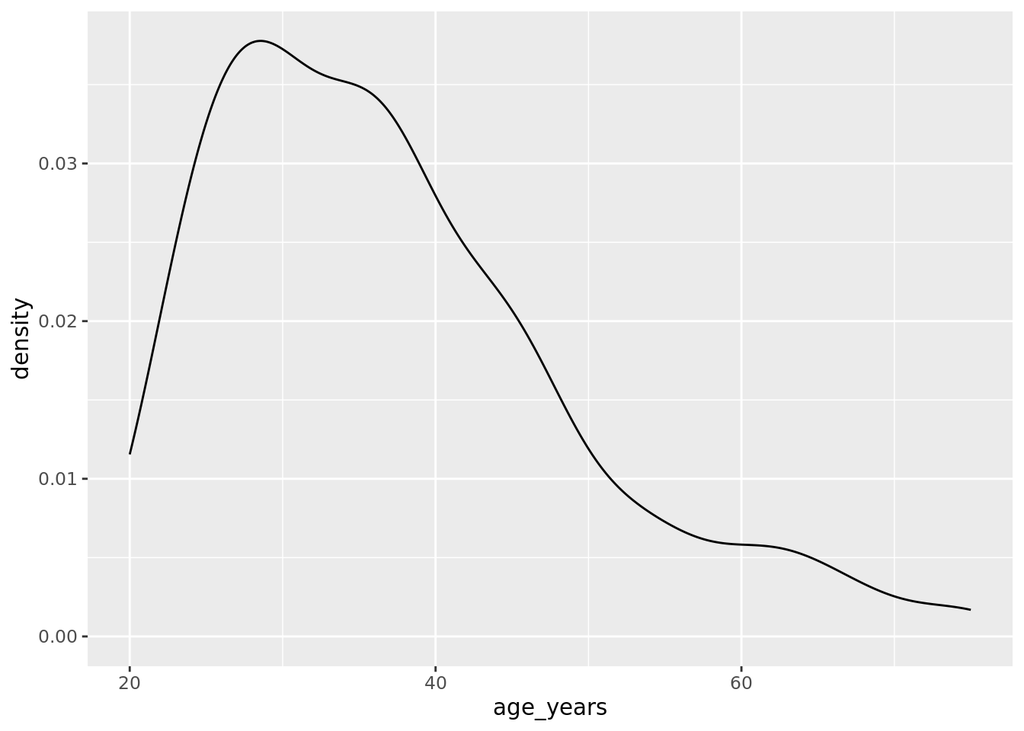

```r
plot_1 <- ggplot(data = data_auto_leningen,
                 aes(x = age_years))

plot_1 + geom_density()
```

## Testen op normaliteit

Statistische test uitvoeren om vast te stellen of de data normaal is verdeeld. Omdat we werken met een relatief kleine subset, kiezen we voor de **Shapiro-Wilk** test.

```r
shapiro.test(data_auto_leningen$age_years)
```

```
##
##  Shapiro-Wilk normality test
##
## data:  data_auto_leningen$age_years
## W = 0.92305, p-value = 3.802e-12
```

**Conclusie:** De variabele `age_years` is niet normaal verdeeld.

# Test uitvoeren

Omdat de data niet normaal verdeeld is, kiezen wij voor een *non-parametrische* test. Wij willen in dit onderzoek twee groepen vergelijken. Daarvoor kiezen wij voor de **Mann-Whitney U** test.

Wij hebben met 2 groepen te maken:

- Leningen voor een gebruikte auto: `car (used)`
- Leningen voor een nieuwe auto: `car (new)`

Puur om te kunnen bekijken, 2 subsets van groepen aanmaken:

```r
# sub-groepen aanmaken
groep_gebruikte_autos <- data_auto_leningen %>%
  filter(purpose == "car (used)")

groep_nieuwe_autos <- data_auto_leningen %>%
  filter(purpose == "car (new)")
```

```r
print(mean(groep_gebruikte_autos$age_years))
```

```
## [1] 37.25243
```

```r
print(mean(groep_nieuwe_autos$age_years))
```

```
## [1] 37.08974
```

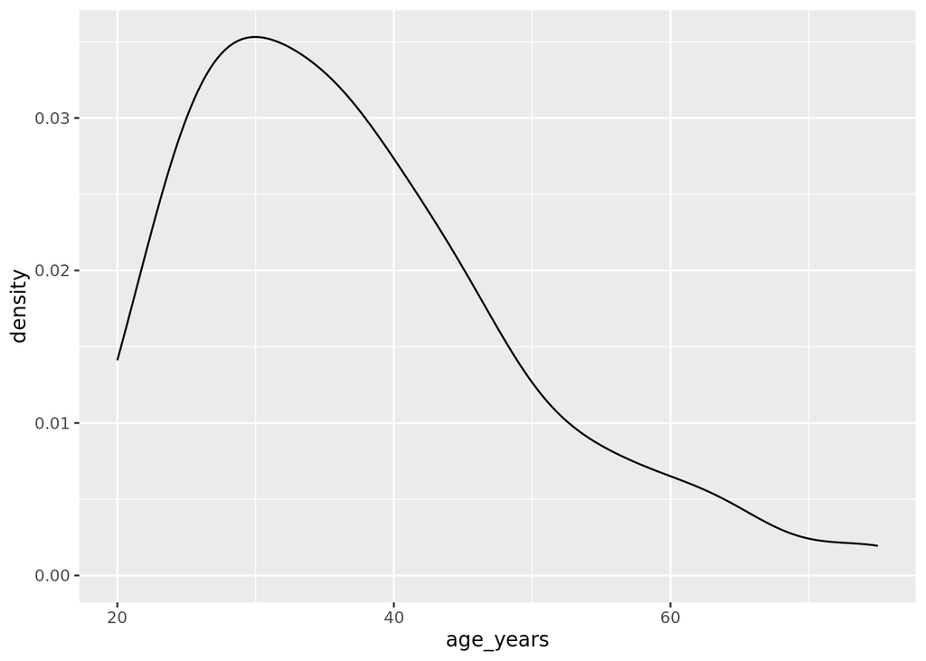

```r
plot_2 <- ggplot(data = groep_gebruikte_autos,
                 aes(x=age_years))

plot_2 + geom_density()
```

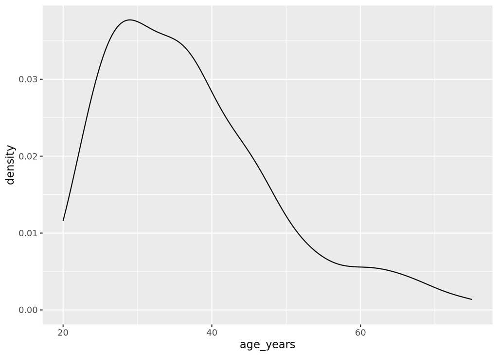

```r
plot_3 <- ggplot(data = groep_nieuwe_autos,
                 aes(x=age_years))

plot_3 + geom_density()
```

Test uitvoeren voor de dataset met de 2 groepen:

```r
wilcox.test(age_years ~ purpose,
            data = data_auto_leningen,
            subset = purpose %in% c("car (new)", "car (used)"))
```

```
##
##  Wilcoxon rank sum test with continuity correction
##
## data:  age_years by purpose
## W = 12076, p-value = 0.9758
## alternative hypothesis: true location shift is not equal to 0
```

De uitkomst van de test heeft een *p-value* van `0.9758`. Dit is groter dan de significantie-waarde van `0.05`.

# Conclusie